# Hierarchical Bayesian Analysis of Radon Data: An Enhanced Hamiltonian Monte Carlo Approach

### County-Level Differences

Next, we explore how radon levels vary by county. A boxplot of log_radon across counties provides a clear visualization of the differences:

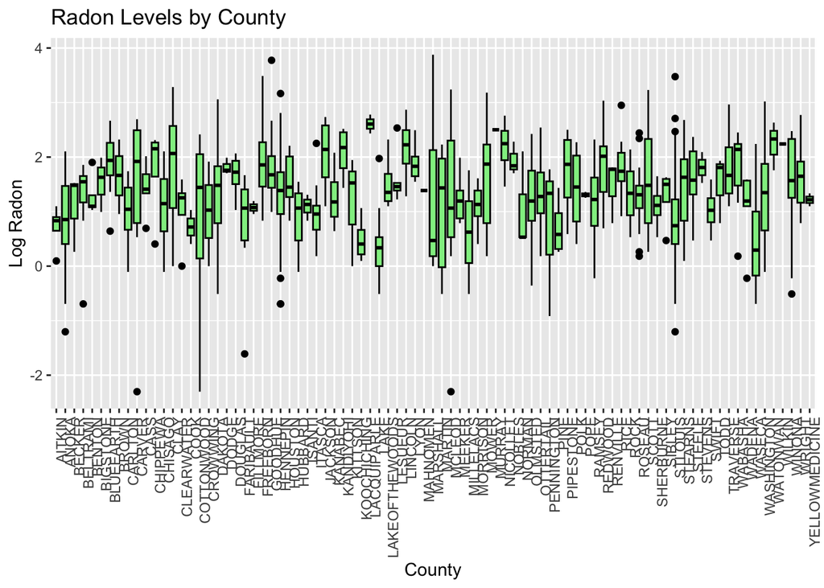

```r
ggplot(radon, aes(x = factor(county), y = log_radon)) +
  geom_boxplot(fill = "lightgreen", color = "black") +
  labs(title = "Radon Levels by County", x = "County", y = "Log Radon") +
  theme(axis.text.x = element_text(angle = 90, hjust = 1))
```

There is clear variation in log radon levels across counties, with some counties showing higher or lower median values than others. Within each county, there is also notable spread in the data. This suggests both between-county and within-county variability and reinforces the need for a hierarchical modeling approach that can capture these different levels of variation.

Additionally, we also compute and plot the mean log radon level for each county:

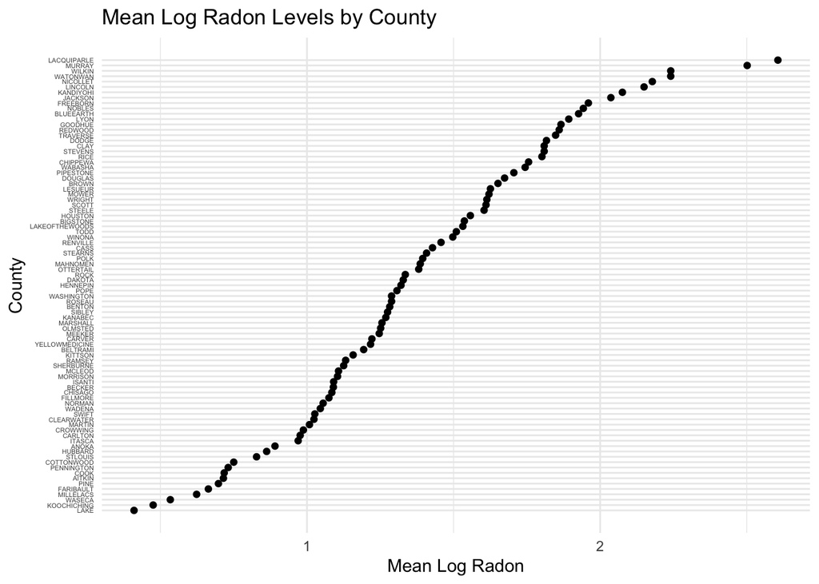

```r
county_summary <- radon %>%
  group_by(county) %>%
  summarise(mean_log_radon = mean(log_radon, na.rm = TRUE),
            n = n())

ggplot(county_summary, aes(x = reorder(county, mean_log_radon), y = mean_log_radon)) +
  geom_point() +
  coord_flip() +
  scale_x_discrete(expand = expansion(mult = c(0.05, 0.05))) +
  labs(title = "Mean Log Radon Levels by County",
       x = "County",
       y = "Mean Log Radon") +
  theme_minimal() +
  theme(axis.text.y = element_text(size = 4))
```

Again, this shows that average radon levels vary noticeably across counties, with some counties having much lower mean log radon than others. The clear gradient from left to right indicates substantial between-county variation, which supports using a hierarchical model to capture these differences alongside the within-county variability.

### Exploring Relevant Predictors

An important predictor in our dataset is the $floor$ variable, which indicates if the measurement is from a basement (0) or an upper floor (1). We examine how radon levels differ based on this predictor:

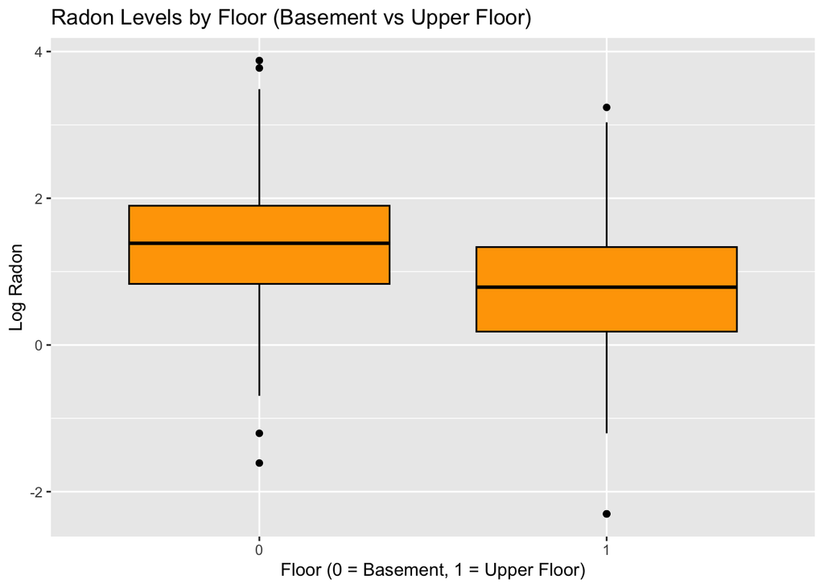

```r
ggplot(radon, aes(x = factor(floor), y = log_radon)) +
  geom_boxplot(fill = "orange", color = "black") +
  labs(title = "Radon Levels by Floor (Basement vs Upper Floor)",
       x = "Floor (0 = Basement, 1 = Upper Floor)", y = "Log Radon")
```

We can see that homes measured in the basement tend to have higher radon levels than those measured on an upper floor. Although there is overlap between the two groups, the boxplot shows a higher median and upper quartile for basement measurements, which aligns with the idea that radon gas often enters through the ground and accumulates more in lower levels of a building.

*Note:* Additionally, including log_uranium as a predictor in the model allows us to account for potential covariate effects that might explain some of the variability in radon levels.

### Identifying the Hierarchical Structure

The radon data are naturally grouped by county, meaning that multiple observations (houses) are nested within each county. This leads to two sources of variability:

- **Within-County Variability:** Variation in radon levels among houses within the same county.
- **Between-County Variability:** Variation in the average radon level from one county to another.

To further illustrate this structure, we summarize key statistics by county:

```r
county_stats <- radon %>%
  group_by(county) %>%
  summarise(n = n(),
            mean_log_radon = mean(log_radon, na.rm = TRUE),
            sd_log_radon = sd(log_radon, na.rm = TRUE))
county_stats
# A tibble: 85 × 4
   county        n mean_log_radon sd_log_radon
   <fct>     <int>          <dbl>        <dbl>
 1 AITKIN        4          0.715        0.432
 2 ANOKA        52          0.891        0.718
 3 BECKER        3          1.09         0.717
 4 BELTRAMI      7          1.19         0.894
 5 BENTON        4          1.28         0.415
 6 BIGSTONE      3          1.54         0.504
 7 BLUEEARTH    14          1.93         0.542
 8 BROWN         4          1.65         0.595
 9 CARLTON      10          0.977        0.585
10 CARVER        6          1.22         1.90
# ℹ 75 more rows
```

The table shows that each of the 85 counties has a different number of observations (n) and distinct mean and standard deviation of log radon levels. Some counties have very few data points (e.g., 3 or 4), while others have many more (e.g., 52). The mean log radon values also vary considerably across counties, as do their standard deviations. This variation in both sample size and radon levels by county underscores the need for a hierarchical model that can account for county-to-county differences (random effects) while borrowing strength across counties.

# 3. Model Specifications

### Hierarchical Model Formulation

We aim to model the log-transformed radon level $y_{ij}$ for house $i$ in county $j$. We include a fixed effect for whether the measurement was taken in the basement (0) or on an upper floor (1). In addition, each county has its own intercept, reflecting the idea that some counties may have generally higher or lower radon levels. Note that this model is inspired by the hierarchical models presented by Gelman and Hill (2007). We can write this as:

$$\begin{aligned}
y_{ij} &\sim \mathcal{N}(\alpha_j + \beta \, x_{ij}, \sigma^2),
\\[6pt]
\alpha_j &\sim \mathcal{N}(\mu_\alpha, \tau^2),
\end{aligned}$$
where:

- $y_{ij}$ is the log radon measurement for house $i$ in county $j$.
- $x_{ij}$ is the floor variable (0 = basement, 1 = upper floor).
- $\alpha_j$ is the county-specific intercept, which follows a normal distribution centered at $\mu_\alpha$ with standard deviation $\tau$.
- $\beta$ is the fixed effect for the floor predictor.
- $\sigma$ is the within-county (house-level) residual standard deviation.
- $\mu_\alpha$ is the overall (global) intercept across all counties.
- $\tau$ captures the between-county variability.

According to Papaspiliopoulos, Roberts, and Sköld (2003), non-centered parameterization can improve sampling efficiency in hierarchical models. Instead of sampling $\alpha_j$ directly, we introduce a latent variable $\alpha_{\text{raw}, j}$ that follows a standard normal, and then transform it:

$$\alpha_j = \mu_\alpha +
\alpha_{\text{raw}, j} \cdot \tau.$$

### Goal of Bayesian Inference

The goal of this Bayesian hierarchical model is to estimate the posterior distributions of all unknown parameters:

- $\beta$ (effect of basement vs. upper floor),
- $\mu_\alpha$ (overall average intercept),
- $\tau$ (between-county variability),
- $\sigma$ (within-county variability), and
- each county-specific intercept $\alpha_j$.

By estimating these posterior distributions, we can quantify both the uncertainty at the county level (how counties differ from one another) and the uncertainty at the house level (residual variability around each county’s intercept).

*Note:* We implemented the above described hierarchical model using non-centered parameterization in the file *radon_model.stan*.